# The Affect of Loan Features on Loan Status Outcome

## Key Insights for Presentation

- Both MonthlyLoanPayment and BorrowerRate affect on the LoanStatus the same, as the Monthly payment increase it is more likely for the loan to be past due. therefore, increases the borrowerRate.
- Borrwers with high ProsperScore seem to take loans with higher monthly payments which results for them to be charged less BorrowerRate.

## Dataset Overview

This dataset contains 113,937 rows and 81 columns, most data are in string objects or int type and a few columns are in float type.

## LoanStatus Vs. MonthlyLoanPayment

> This box plot shows that`MonthlyLoanPayment` does have an affect on `LoanStatus`, Past Due loans seems to have more average monthly payment than those that are Completed, So the higher the monthly payment the more likely to be past due.

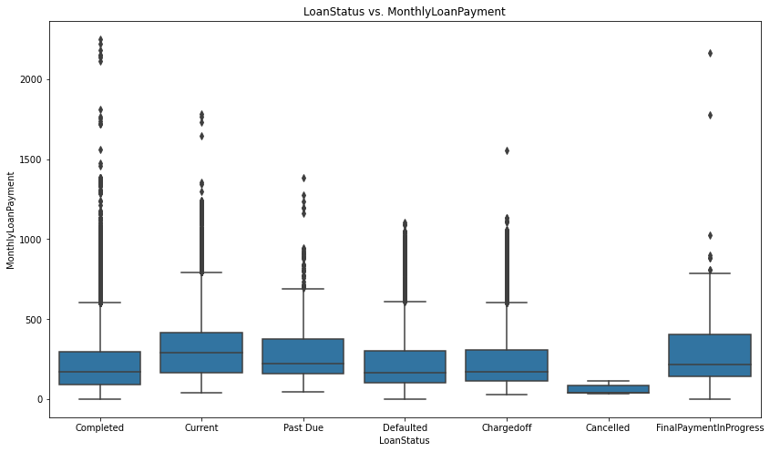

## LoanStatus Vs. Prosper Score

> `ProsperScore` seems to have an affect on `LoanStatus`, borrowers with 8.0 score seem to be the most in Completed status, while borrwers with score 4.0 are the most borrowers with current loans, As for Chargedoff loans borrwers with score 6.0 seem to have the most chargedoff loans.

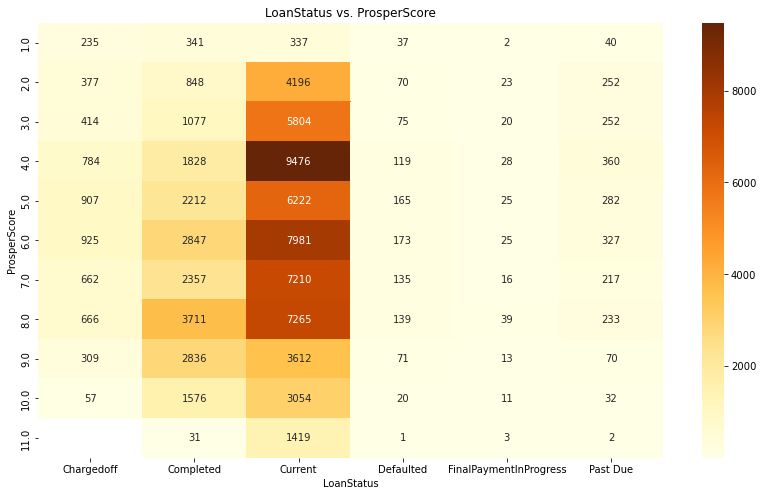

## LoanStatus Vs. BorrowerRate

> average `BorrwerRate` increases when the `LoanStatus` is Past Due or Chargedoff.

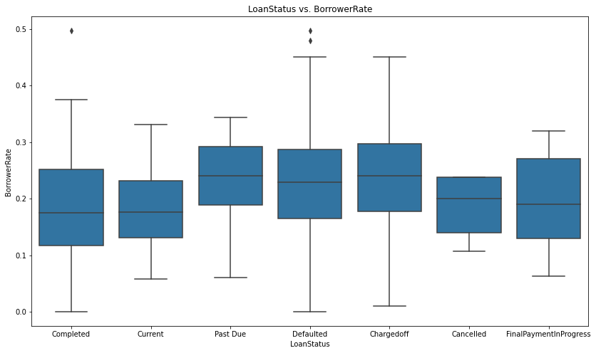

## Loan Status Vs. MonthlyLoanPayment Vs. BorrowerRate Vs. ProsperScore

> This multivariate violin plot shows the follwing:
> - Both MonthlyLoanPayment and BorrowerRate affect on the LoanStatus the same, as the Monthly payment increase it is more likely for the loan to be past due. therefore, increases the borrowerRate.
> - Borrwers with high ProsperScore seem to take loans with higher monthly payments which results for them to be charged less BorrowerRate.

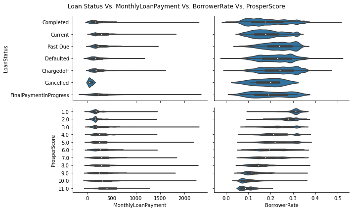